# CAPÍTULO N° 2 - Modelamiento Estadístico

2022-06-09

**Capítulo N° 2 recuperado de [Estadísticas modernas para la biología moderna](https://web.stanford.edu/class/bios221/book/Chap-Models.html)**

### Paquetes

```r
#install.packages("pacman")
library(pacman)
p_load("vcd", "Biostrings","HardyWeinberg","seqLogo","markovchain","igraph","Biostrings","BSgenome",
       "BSgenome.Ecoli.NCBI.20080805","Renext","BSgenome.Hsapiens.UCSC.hg19","Gviz")
```

Hay dos partes en el procedimiento de modelado. Primero se necesita una distribución para modelar el proceso de generación de datos. Los datos de conteo discretos pueden modelarse mediante distribuciones de probabilidad simples, como las distribuciones binomial, multinomial o de Poisson.

## 2.3 Un ejemplo simple de modelado estadístico

Descargar el conjunto de datos de [este link](https://github.com/unalmdei/GuiaBioinformatica/blob/master/Datos/Cap2/e100.RData)

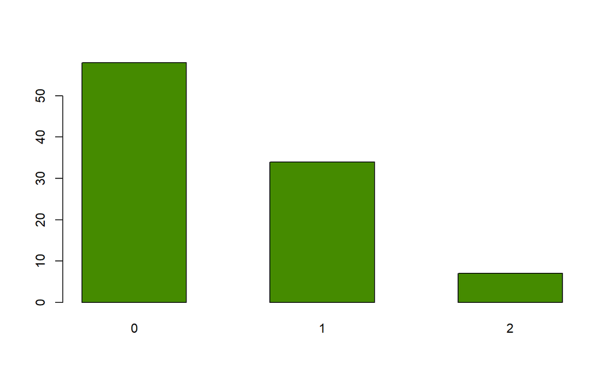

```r
#Cargar el archivo "e100.RData"

load("../data/e100.RData")
e99 = e100[-which.max(e100)]
barplot(table(e99), space = 0.8, col = "chartreuse4")
```

Rootograma que muestra la raíz cuadrada de los valores teóricos como puntos rojos y la raíz cuadrada de las frecuencias observadas como rectángulos desplegables

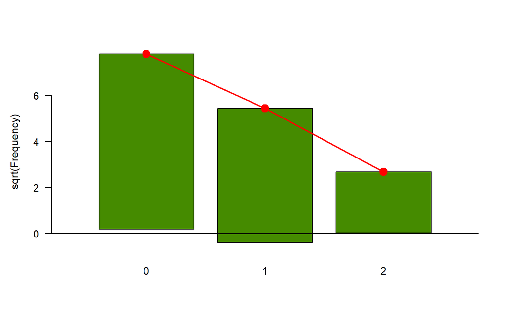

```r
#library("vcd")
gf1 = goodfit( e99, "poisson")
rootogram(gf1, xlab = "", rect_gp = gpar(fill = "chartreuse4"))
```

### Estimación del parámetro de la distribución de Poisson

```r
#Cantidad de datos por categoria
table(e100)
```

```
## e100
##  0  1  2  7
## 58 34  7  1
```

Se prueba diferentes valores para la media de Poisson y se cuál se ajusta mejor datos.

```r
table(rpois(100, 3))
```

```
##
##  0  1  2  3  4  5  6  7  8
##  6 16 20 21 23 10  2  1  1
```

```r
prod(dpois(c(0, 1, 2, 7), lambda = 3))
```

```
## [1] 3.599302e-05
```

### Función de verosimilitud de λ

```r
loglikelihood  =  function(lambda, data = e100) {
  sum(log(dpois(data, lambda)))
}

lambdas = seq(0.05, 0.95, length = 100)
loglik = vapply(lambdas, loglikelihood, numeric(1))
m0 = mean(e100)
m0
```

```
## [1] 0.55
```

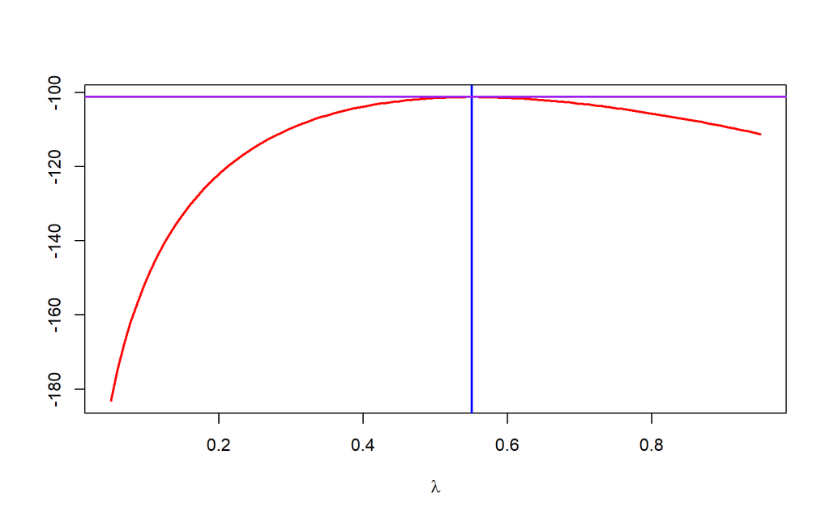

```r
plot(lambdas, loglik, type = "l", col = "red", ylab = "", lwd = 2,
     xlab = expression(lambda))
abline(v = m0, col = "blue", lwd = 2)
abline(h = loglikelihood(m0), col = "purple", lwd = 2)
```

La curva roja es la función logarítmica de verosimilitud. La línea vertical muestra el valor de m (la media) y la línea horizontal el log-verosimilitud de m.

```r
gf  =  goodfit(e100, "poisson")
names(gf)
```

```
## [1] "observed" "count"    "fitted"   "type"     "method"   "df"       "par"
```

```r
gf$par
```

```
## $lambda
## [1] 0.55
```

La salida de goodfites un objeto compuesto llamado lista. Uno de sus componentes se llama par y contiene los valores de los parámetros ajustados para la distribución estudiada. En este caso es solo un número, la estimación de λ .

## 2.4 Distribuciones binomiales y máxima verosimilitud

```r
cb  =  c(rep(0, 110), rep(1, 10))
table(cb)
```

```
## cb
##   0   1
## 110  10
```

```r
mean(cb)
```

```
## [1] 0.08333333
```

Si se calcula la probabilidad de muchos posibles p , Se puede trazar y ver dónde cae su máximo.

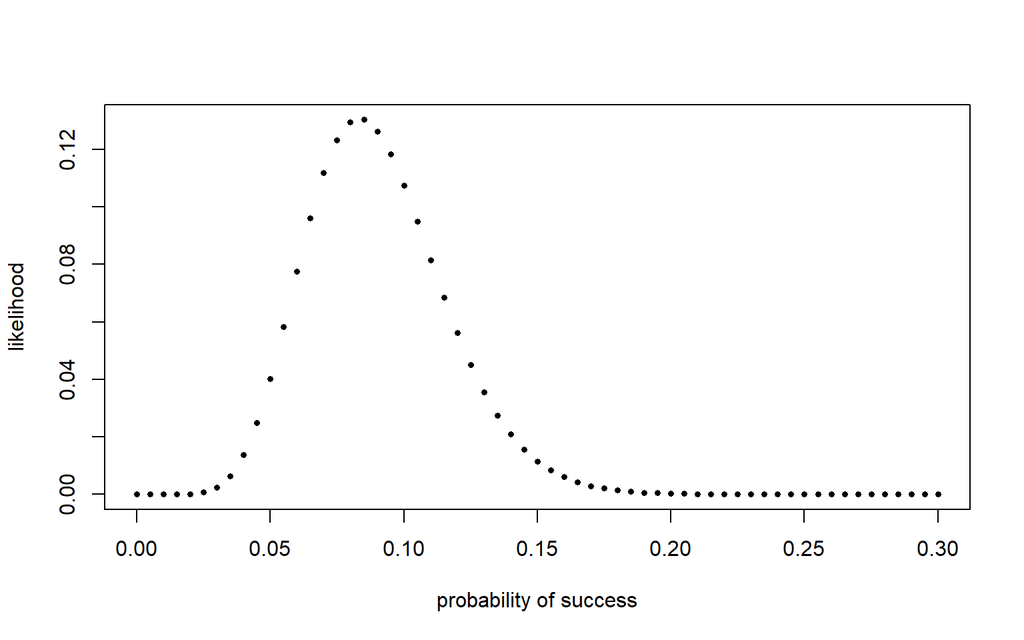

```r
probs  =  seq(0, 0.3, by = 0.005)
likelihood = dbinom(sum(cb), prob = probs, size = length(cb))
plot(probs, likelihood, pch = 16, xlab = "probability of success",
       ylab = "likelihood", cex=0.6)
```

```r
probs[which.max(likelihood)]
```

```
## [1] 0.085
```

```r
stopifnot(abs(probs[which.max(likelihood)]-1/12) < diff(probs[1:2]))
```

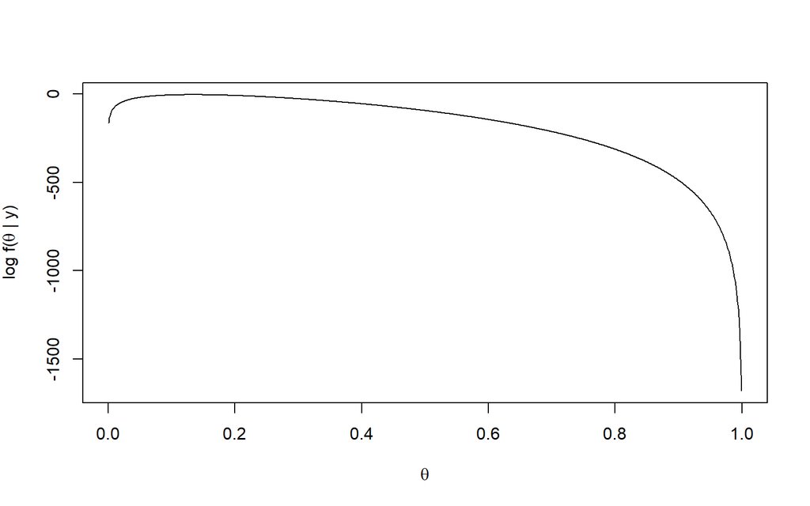

```r
#verosimilitud

loglikelihood = function(theta, n = 300, k = 40) {
  115 + k * log(theta) + (n - k) * log(1 - theta)
}

thetas = seq(0, 1, by = 0.001)
plot(thetas, loglikelihood(thetas), xlab = expression(theta),
  ylab = expression(paste("log f(", theta, " | y)")),type = "l")
```

## 2.5 Más casillas:datos multinomiales

### 2.5.2 Sesgo de nucleótidos

El conjunto de datos se encuentra en [este link](https://github.com/unalmdei/GuiaBioinformatica/blob/master/Datos/Cap2/staphsequence.ffn.txt)

```r
p_load("Biostrings")
staph = readDNAStringSet("https://raw.githubusercontent.com/unalmdei/GuiaBioinformatica/master/Datos/Cap2/staphsequence.ffn.txt", "fasta")
staph
```

```
## DNAStringSet object of length 2650:
##        width seq                                            names
##    [1]  1362 ATGTCGGAAAAAGAAATTTGGG...AAAGAAATAAGAAATGTATAA lcl|NC_002952.2_c...
##    [2]  1134 ATGATGGAATTCACTATTAAAA...TTACCAATCAGAACTTACTAA lcl|NC_002952.2_c...
##    [3]   246 GTGATTATTTTGGTTCAAGAAG...ATTCATCAAGGTGAACAATGA lcl|NC_002952.2_c...
##    [4]  1113 ATGAAGTTAAATACACTCCAAT...CAAGGTGAAATTATAAAGTAA lcl|NC_002952.2_c...
##    [5]  1932 GTGACTGCATTGTCAGATGTAA...TATGCAAACTTAGACTTCTAA lcl|NC_002952.2_c...
##    ...   ... ...
## [2646]   720 ATGACTGTAGAATGGTTAGCAG...ACTCCTTTACTTGAAAAATAA lcl|NC_002952.2_c...
## [2647]  1878 GTGGTTCAAGAATATGATGTAA...CTCCAAAGGGTGAGTGACTAA lcl|NC_002952.2_c...
## [2648]  1380 ATGGATTTAGATACAATTACGA...CAATTCTGCTTAGGTAAATAG lcl|NC_002952.2_c...
## [2649]   348 TTGGAAAAAGCTTACCGAATTA...TTTAATAAAAAGATTAAGTAA lcl|NC_002952.2_c...
## [2650]   138 ATGGTAAAACGTACTTATCAAC...CGTAAAGTTTTATCTGCATAA lcl|NC_002952.2_c...
```

```r
#primer gen
staph[1]
```

```
## DNAStringSet object of length 1:
##     width seq                                               names
## [1]  1362 ATGTCGGAAAAAGAAATTTGGGA...AAAAAGAAATAAGAAATGTATAA lcl|NC_002952.2_c...
```

```r
letterFrequency(staph[[1]], letters = "ACGT", OR = 0)
```

```
##   A   C   G   T
## 522 219 229 392
```

```r
letterFrq = vapply(staph, letterFrequency, FUN.VALUE = numeric(4),
         letters = "ACGT", OR = 0)
colnames(letterFrq) = paste0("gene", seq(along = staph))
tab10 = letterFrq[, 1:10]
computeProportions = function(x) { x/sum(x) }
prop10 = apply(tab10, 2, computeProportions)
round(prop10, digits = 2)
```

```
##   gene1 gene2 gene3 gene4 gene5 gene6 gene7 gene8 gene9 gene10
## A  0.38  0.36  0.35  0.37  0.35  0.33  0.33  0.34  0.38   0.27
## C  0.16  0.16  0.13  0.15  0.15  0.15  0.16  0.16  0.14   0.16
## G  0.17  0.17  0.23  0.19  0.22  0.22  0.20  0.21  0.20   0.20
## T  0.29  0.31  0.30  0.29  0.27  0.30  0.30  0.29  0.28   0.36
```

```r
p0 = rowMeans(prop10)
p0
```

```
##         A         C         G         T
## 0.3470531 0.1518313 0.2011442 0.2999714
```

```r
cs = colSums(tab10)
cs
```

```
##  gene1  gene2  gene3  gene4  gene5  gene6  gene7  gene8  gene9 gene10
##   1362   1134    246   1113   1932   2661    831   1515   1287    696
```

```r
expectedtab10 = outer(p0, cs, FUN = "*")
round(expectedtab10)
```

```
##   gene1 gene2 gene3 gene4 gene5 gene6 gene7 gene8 gene9 gene10
## A   473   394    85   386   671   924   288   526   447    242
## C   207   172    37   169   293   404   126   230   195    106
## G   274   228    49   224   389   535   167   305   259    140
## T   409   340    74   334   580   798   249   454   386    209
```

```r
randomtab10 = sapply(cs, function(s) { rmultinom(1, s, p0) } )
all(colSums(randomtab10) == cs)
```

```
## [1] TRUE
```

```r
stat = function(obsvd, exptd = 20 * pvec) {
   sum((obsvd - exptd)^2 / exptd)
}
B = 1000
simulstat = replicate(B, {
  randomtab10 = sapply(cs, function(s) { rmultinom(1, s, p0) })
  stat(randomtab10, expectedtab10)
})
S1 = stat(tab10, expectedtab10)
sum(simulstat >= S1)
```

```
## [1] 0
```

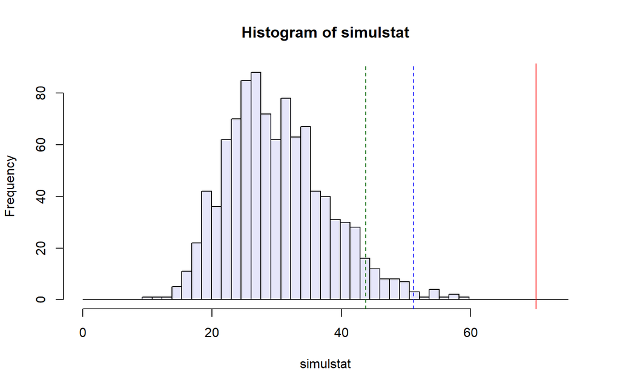

```r
hist(simulstat, col = "lavender", breaks = seq(0, 75, length.out=50))
abline(v = S1, col = "red")
abline(v = quantile(simulstat, probs = c(0.95, 0.99)),
       col = c("darkgreen", "blue"), lty = 2)
```

## 2.6 La distribución Chi-Cuadrado

### 2.6.1 Intermezzo: cuantiles y gráfico cuantil-cuantil

```r
qs = ppoints(100)
quantile(simulstat, qs)
```

```
##     0.5%     1.5%     2.5%     3.5%     4.5%     5.5%     6.5%     7.5%
## 14.52251 16.58740 17.46513 18.01204 18.55162 18.97097 19.30633 19.61577
##     8.5%     9.5%    10.5%    11.5%    12.5%    13.5%    14.5%    15.5%
## 19.97305 20.60482 21.01181 21.32514 21.57260 21.83745 22.10061 22.37277
##    16.5%    17.5%    18.5%    19.5%    20.5%    21.5%    22.5%    23.5%
## 22.53970 22.84646 23.09214 23.26769 23.56263 23.66331 23.86775 24.07575
##    24.5%    25.5%    26.5%    27.5%    28.5%    29.5%    30.5%    31.5%
## 24.28341 24.57395 24.70650 24.93031 25.05598 25.28856 25.52754 25.70975
##    32.5%    33.5%    34.5%    35.5%    36.5%    37.5%    38.5%    39.5%
## 25.92013 25.99932 26.14243 26.33959 26.51530 26.60742 26.78114 27.06485
##    40.5%    41.5%    42.5%    43.5%    44.5%    45.5%    46.5%    47.5%
## 27.26460 27.38950 27.55911 27.74677 27.98111 28.21055 28.52398 28.79868
##    48.5%    49.5%    50.5%    51.5%    52.5%    53.5%    54.5%    55.5%
## 28.96634 29.07116 29.37496 29.53454 29.80030 30.04826 30.24077 30.49242
##    56.5%    57.5%    58.5%    59.5%    60.5%    61.5%    62.5%    63.5%
## 30.83797 31.11261 31.23086 31.44174 31.52498 31.69540 31.86591 32.12907
##    64.5%    65.5%    66.5%    67.5%    68.5%    69.5%    70.5%    71.5%
## 32.43137 32.65958 32.78924 32.95392 33.14838 33.41145 33.72826 33.93391
##    72.5%    73.5%    74.5%    75.5%    76.5%    77.5%    78.5%    79.5%
## 34.20929 34.44995 34.69099 34.90657 35.13308 35.42322 35.68791 36.05806
##    80.5%    81.5%    82.5%    83.5%    84.5%    85.5%    86.5%    87.5%
## 36.59217 37.06615 37.57260 37.88997 38.13226 38.64151 39.05776 39.65148
##    88.5%    89.5%    90.5%    91.5%    92.5%    93.5%    94.5%    95.5%
## 39.89818 40.35745 40.82605 41.83882 42.28731 42.73963 43.32663 44.46853
##    96.5%    97.5%    98.5%    99.5%
## 45.79301 47.90739 49.81201 54.23890
```

```r
quantile(qchisq(qs, df = 30), qs)
```

```
##     0.5%     1.5%     2.5%     3.5%     4.5%     5.5%     6.5%     7.5%
## 14.74308 16.23869 17.16382 17.87179 18.45879 18.96730 19.42030 19.83175
##     8.5%     9.5%    10.5%    11.5%    12.5%    13.5%    14.5%    15.5%
## 20.21086 20.56401 20.89588 21.20996 21.50896 21.79501 22.06984 22.33486
##    16.5%    17.5%    18.5%    19.5%    20.5%    21.5%    22.5%    23.5%
## 22.59125 22.83999 23.08192 23.31776 23.54813 23.77359 23.99461 24.21163
##    24.5%    25.5%    26.5%    27.5%    28.5%    29.5%    30.5%    31.5%
## 24.42502 24.63512 24.84224 25.04668 25.24867 25.44846 25.64627 25.84230
##    32.5%    33.5%    34.5%    35.5%    36.5%    37.5%    38.5%    39.5%
## 26.03673 26.22975 26.42152 26.61219 26.80192 26.99084 27.17910 27.36683
##    40.5%    41.5%    42.5%    43.5%    44.5%    45.5%    46.5%    47.5%
## 27.55414 27.74118 27.92804 28.11486 28.30175 28.48883 28.67621 28.86400
##    48.5%    49.5%    50.5%    51.5%    52.5%    53.5%    54.5%    55.5%
## 29.05231 29.24127 29.43100 29.62161 29.81322 30.00595 30.19994 30.39530
##    56.5%    57.5%    58.5%    59.5%    60.5%    61.5%    62.5%    63.5%
## 30.59219 30.79073 30.99107 31.19337 31.39779 31.60450 31.81367 32.02550
##    64.5%    65.5%    66.5%    67.5%    68.5%    69.5%    70.5%    71.5%
## 32.24019 32.45796 32.67904 32.90367 33.13213 33.36471 33.60172 33.84351
##    72.5%    73.5%    74.5%    75.5%    76.5%    77.5%    78.5%    79.5%
## 34.09046 34.34299 34.60155 34.86665 35.13886 35.41883 35.70725 36.00496
##    80.5%    81.5%    82.5%    83.5%    84.5%    85.5%    86.5%    87.5%
## 36.31286 36.63203 36.96368 37.30925 37.67041 38.04916 38.44789 38.86951
##    88.5%    89.5%    90.5%    91.5%    92.5%    93.5%    94.5%    95.5%
## 39.31761 39.79669 40.31253 40.87266 41.48728 42.17057 42.94329 43.83752
##    96.5%    97.5%    98.5%    99.5%
## 44.90723 46.25504 48.12235 51.45778
```

¿Cómo se calcula el cuantil para cualquier número entre 0 y 1, incluidos los que no son múltiplos de 1 / n?

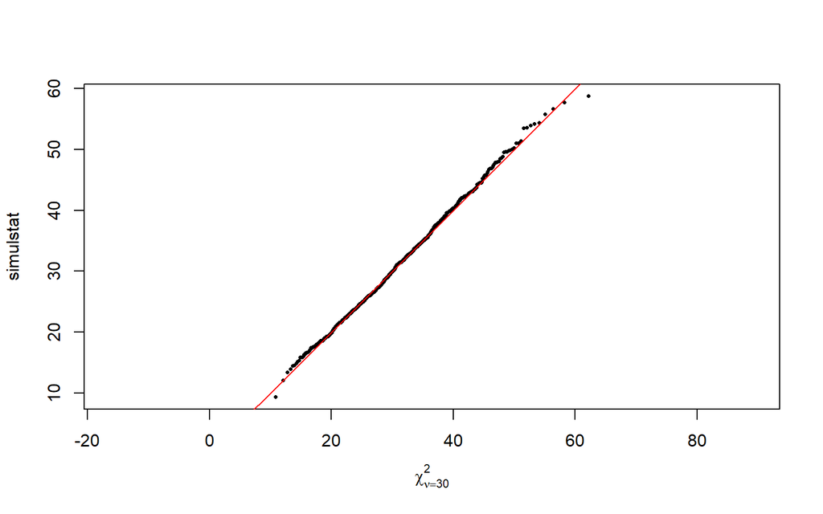

```r
qqplot(qchisq(ppoints(B), df = 30), simulstat, main = "",
  xlab = expression(chi[nu==30]^2), asp = 1, cex = 0.5, pch = 16)
abline(a = 0, b = 1, col = "red")
```

```r
1 - pchisq(S1, df = 30)
```

```
## [1] 4.74342e-05
```

## 2.7 Regla de Chargaff

El conjunto de datos se encuentra en [este link](https://github.com/unalmdei/GuiaBioinformatica/blob/master/Datos/Cap2/ChargaffTable.RData)

```r
load("../data/ChargaffTable.RData")
ChargaffTable
```

```
##                   A    T    C    G
## Human-Thymus   30.9 29.4 19.9 19.8
## Mycobac.Tuber  15.1 14.6 34.9 35.4
## Chicken-Eryth. 28.8 29.2 20.5 21.5
## Sheep-liver    29.3 29.3 20.5 20.7
## Sea Urchin     32.8 32.1 17.7 17.3
## Wheat          27.3 27.1 22.7 22.8
## Yeast          31.3 32.9 18.7 17.1
## E.coli         24.7 23.6 26.0 25.7
```

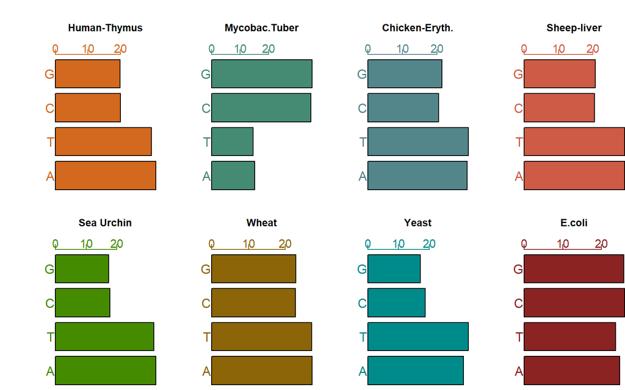

```r
stopifnot(nrow(ChargaffTable) == 8)
mycolors = c("chocolate", "aquamarine4", "cadetblue4", "coral3",
            "chartreuse4","darkgoldenrod4","darkcyan","brown4")
par(mfrow=c(2, 4), mai = c(0, 0.7, 0.7, 0))
for (i in 1:8) {
  cbp = barplot(ChargaffTable[i, ], horiz = TRUE, axes = FALSE, axisnames = FALSE, col = mycolors[i])
  ax = axis(3, las = 2, labels = FALSE, col = mycolors[i], cex = 0.5, at = c(0, 10, 20))
  mtext(side = 3, at = ax,  text = paste(ax), col = mycolors[i], line = 0, las = 1, cex = 0.9)
  mtext(side = 2, at = cbp, text = colnames(ChargaffTable), col = mycolors[i], line = 0, las = 2, cex = 1)
  title(paste(rownames(ChargaffTable)[i]), col = mycolors[i], cex = 1.1)
}
```

### 2.7.1 Dos variables categóricas

```r
statChf = function(x){
  sum((x[, "C"] - x[, "G"])^2 + (x[, "A"] - x[, "T"])^2)
}
chfstat = statChf(ChargaffTable)
permstat = replicate(100000, {
     permuted = t(apply(ChargaffTable, 1, sample))
     colnames(permuted) = colnames(ChargaffTable)
     statChf(permuted)
})
pChf = mean(permstat <= chfstat)
pChf
```

```
## [1] 0.00019
```

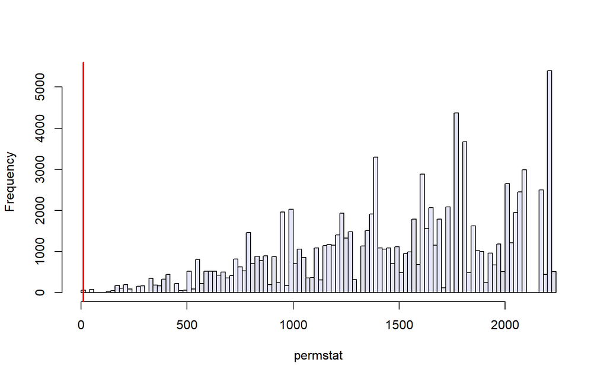

```r
hist(permstat, breaks = 100, main = "", col = "lavender")
abline(v = chfstat, lwd = 2, col = "red")
```

```r
# tabla de contingencia
HairEyeColor[,, "Female"]
```

```
##        Eye
## Hair    Brown Blue Hazel Green
##   Black    36    9     5     2
##   Brown    66   34    29    14
##   Red      16    7     7     7
##   Blond     4   64     5     8
```

```r
str(HairEyeColor)
```

```
##  'table' num [1:4, 1:4, 1:2] 32 53 10 3 11 50 10 30 10 25 ...
##  - attr(*, "dimnames")=List of 3
##   ..$ Hair: chr [1:4] "Black" "Brown" "Red" "Blond"
##   ..$ Eye : chr [1:4] "Brown" "Blue" "Hazel" "Green"
##   ..$ Sex : chr [1:2] "Male" "Female"
```

El conjunto de datos se encuentra en [este link](https://github.com/unalmdei/GuiaBioinformatica/blob/master/Datos/Cap2/Deuteranopia.RData)

```r
#browseURL("https://github.com/unalmdei/GuiaBioinformatica/blob/master/Datos/Cap2/Deuteranopia.RData")

load("../data/Deuteranopia.RData")
Deuteranopia
```

```
##           Men Women
## Deute      19     2
## NonDeute 1981  1998
```

Se postula el modelo nulo con dos binomios independientes: uno para sexo y otro para daltonismo. Bajo este modelo se puede estimar todas las probabilidades multinomiales de las celdas y se puede comparar los conteos observados con los esperados.

```r
chisq.test(Deuteranopia)
```

```
##
##  Pearson's Chi-squared test with Yates' continuity correction
##
## data:  Deuteranopia
## X-squared = 12.255, df = 1, p-value = 0.0004641
```

### 2.7.2 Un multinomio especial: equilibrio de Hardy-Weinberg

```r
library("HardyWeinberg")
data("Mourant")
Mourant[214:216,]
```

```
##     Population    Country Total  MM  MN  NN
## 214    Oceania Micronesia   962 228 436 298
## 215    Oceania Micronesia   678  36 229 413
## 216    Oceania     Tahiti   580 188 296  96
```

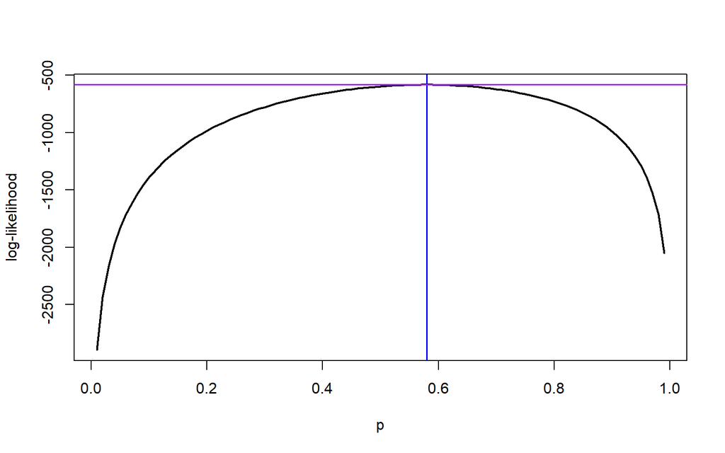

```r
nMM = Mourant$MM[216]
nMN = Mourant$MN[216]
nNN = Mourant$NN[216]
loglik = function(p, q = 1 - p) {
  2 * nMM * log(p) + nMN * log(2*p*q) + 2 * nNN * log(q)
}
xv = seq(0.01, 0.99, by = 0.01)
yv = loglik(xv)
plot(x = xv, y = yv, type = "l", lwd = 2,
     xlab = "p", ylab = "log-likelihood")
imax = which.max(yv)
abline(v = xv[imax], h = yv[imax], lwd = 1.5, col = "blue")
abline(h = yv[imax], lwd = 1.5, col = "purple")
```

```r
#utilizando el affunción del HardyWeinberg
phat  =  af(c(nMM, nMN, nNN))
phat
```

```
## [1] 0.5793103
```

```r
pMM   =  phat^2
qhat  =  1 - phat

#Los valores esperados bajo el equilibrio de Hardy-Weinberg son entonces

pHW = c(MM = phat^2, MN = 2*phat*qhat, NN = qhat^2)
sum(c(nMM, nMN, nNN)) * pHW
```

```
##       MM       MN       NN
## 194.6483 282.7034 102.6483
```

### Comparación visual con el equilibrio de Hardy-Weinberg

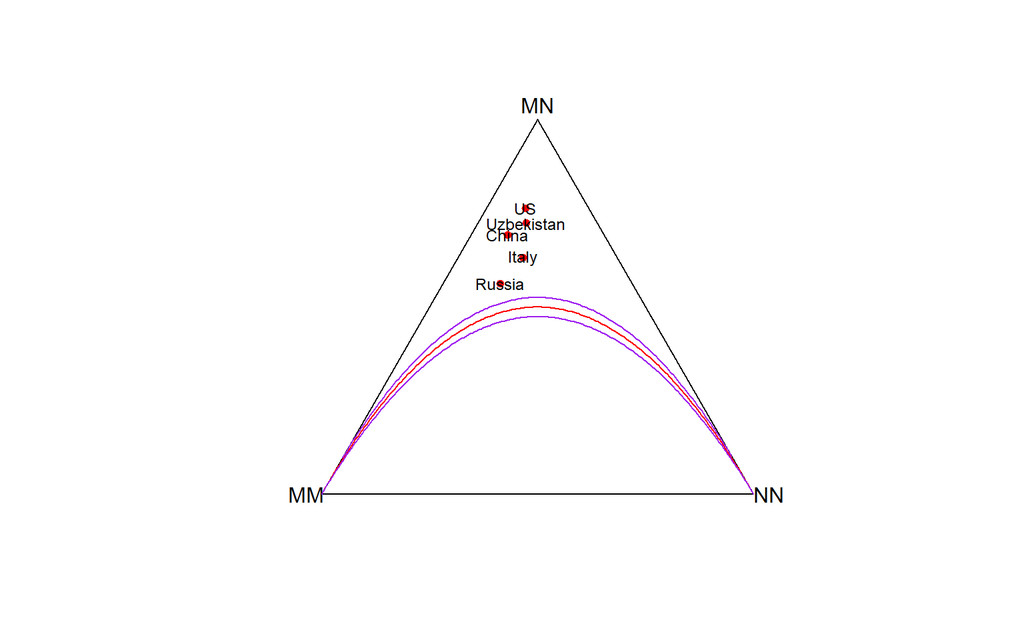

```r
pops = c(1, 69, 128, 148, 192)
genotypeFrequencies = as.matrix(Mourant[, c("MM", "MN", "NN")])
HWTernaryPlot(genotypeFrequencies[pops, ],
        markerlab = Mourant$Country[pops],
        alpha = 0.0001, curvecols = c("red", rep("purple", 4)),
        mcex = 0.75, vertex.cex = 1)
```

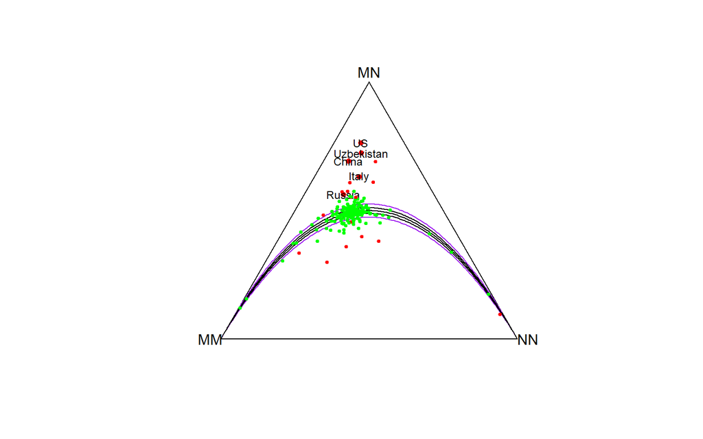

```r
HWTernaryPlot(genotypeFrequencies[pops, ],
        markerlab = Mourant$Country[pops],
        alpha = 0.0001, curvecols = c("red", rep("purple", 4)),
        mcex = 0.75, vertex.cex = 1)
HWTernaryPlot(genotypeFrequencies[-pops, ], alpha = 0.0001,
   newframe = FALSE, cex = 0.5)
```

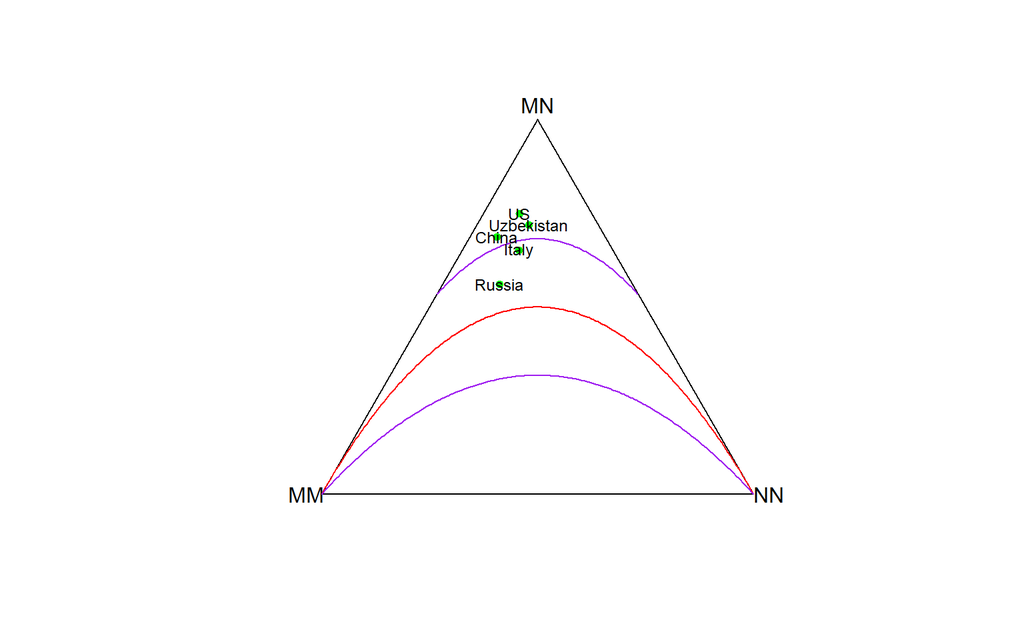

```r
newgf = round(genotypeFrequencies / 50)
HWTernaryPlot(newgf[pops, ],
        markerlab = Mourant$Country[pops],
        alpha = 0.0001, curvecols = c("red", rep("purple", 4)),
        mcex = 0.75, vertex.cex = 1)
```

### 2.7.3 Concatenación de varios multinomios: motivos de secuencia y logos

El conjunto de datos se encuentra en [este link](https://github.com/unalmdei/GuiaBioinformatica/blob/master/Datos/Cap2/kozak.RData)

```r
library("seqLogo")
load("../data/kozak.RData")
kozak
```

```
##   [,1] [,2] [,3] [,4] [,5] [,6] [,7] [,8] [,9]
## A 0.33 0.25  0.4 0.15 0.20    1    0    0 0.05
## C 0.12 0.25  0.1 0.40 0.40    0    0    0 0.05
## G 0.33 0.25  0.4 0.20 0.25    0    0    1 0.90
## T 0.22 0.25  0.1 0.25 0.15    0    1    0 0.00
```

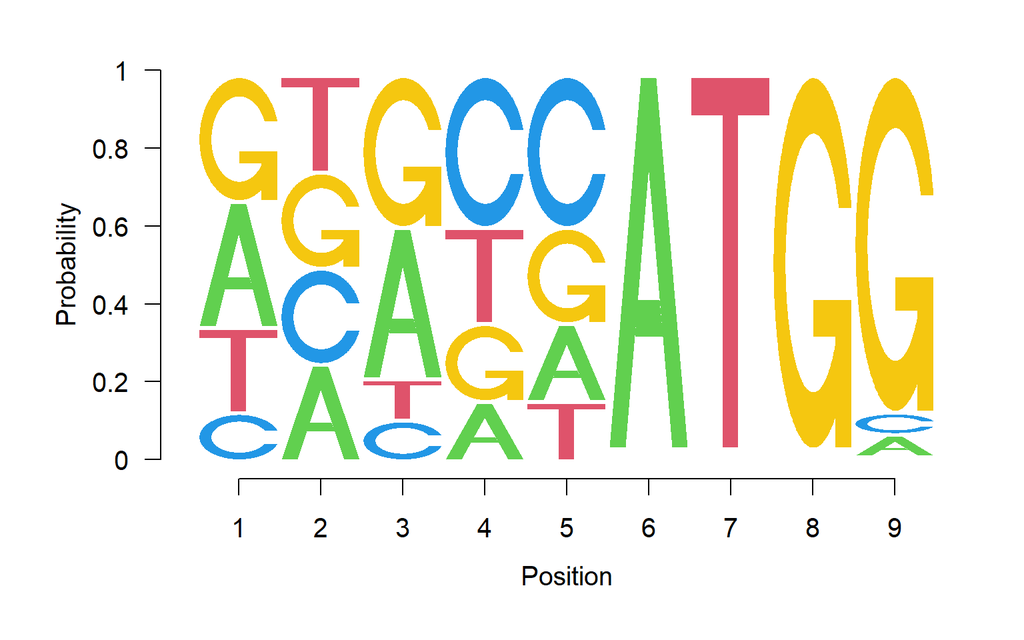

```r
pwm = makePWM(kozak)
seqLogo(pwm, ic.scale = FALSE)
```

## 2.8 Modelado de dependencias secuenciales: cadenas de Markov

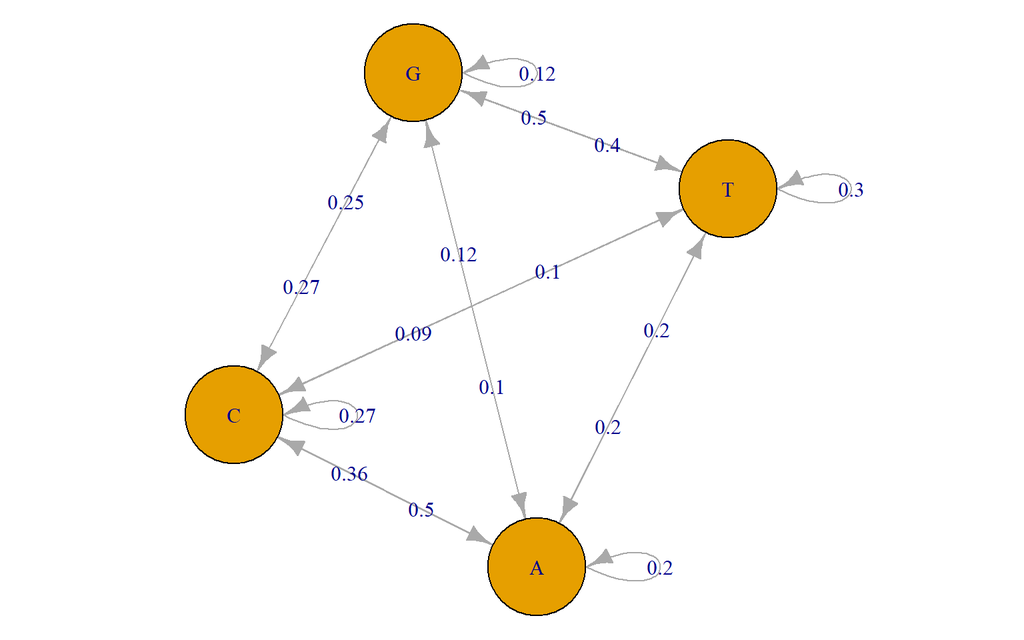

```r
library("markovchain")
library("igraph")
sequence = toupper(c("a", "c", "a", "c", "g", "t", "t", "t", "t", "c",
"c", "a", "c", "g", "t", "a", "c","c","c","a","a","a","t","a",
"c","g","g","c","a","t","g","t","g","t","g","a","g","c","t","g"))
mcFit   =  markovchainFit(data = sequence)
MCgraph =  markovchain:::.getNet(mcFit$estimate, round = TRUE)
edgelab =  round(E(MCgraph)$weight / 100, 2)
par(mai=c(0,0,0,0))
plot.igraph(MCgraph, edge.label = edgelab,
       vertex.size = 40, xlim = c(-1, 1.25))
```

## 2.9 Pensamiento bayesiano

### haplotipos

El conjunto de datos se encuentra en [este link](https://github.com/unalmdei/GuiaBioinformatica/blob/master/Datos/Cap2/haplotype6.txt)

```r
haplo6=read.table("https://raw.githubusercontent.com/unalmdei/GuiaBioinformatica/master/Datos/Cap2/haplotype6.txt",header = TRUE)
haplo6
```

```
##   Individual DYS19 DXYS156Y DYS389m DYS389n DYS389p
## 1         H1    14       12       4      12       3
## 2         H3    15       13       4      13       3
## 3         H4    15       11       5      11       3
## 4         H5    17       13       4      11       3
## 5         H7    13       12       5      12       3
## 6         H8    16       11       5      12       3
```

### 2.9.2 Estudio de simulación del paradigma bayesiano para el binomio

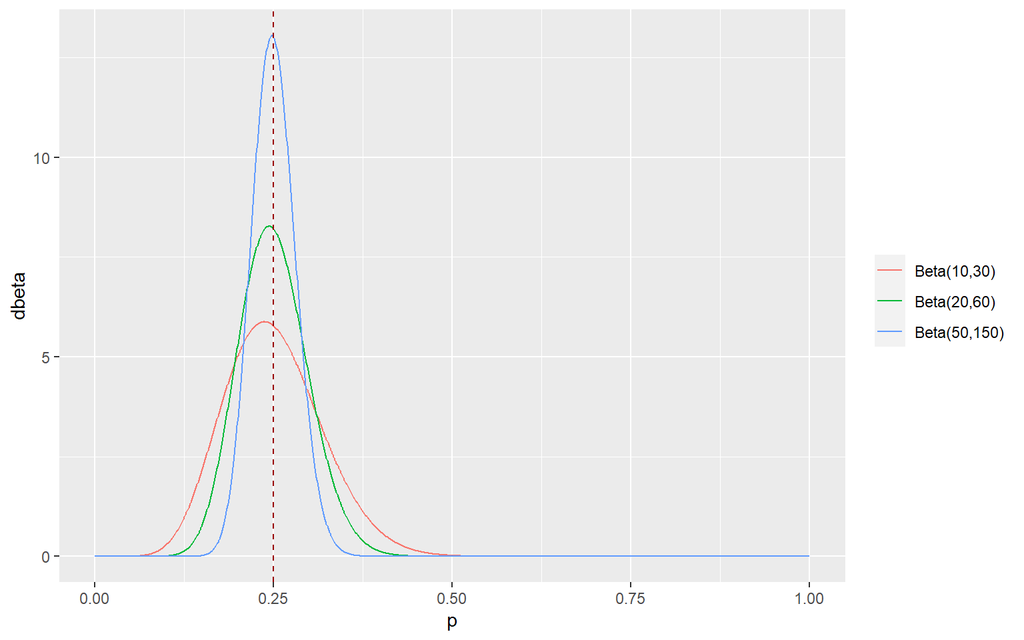

```r
library(ggplot2)
dfbetas = data.frame(
  p = rep(thetas, 3),
  dbeta = c(dbeta(thetas,  10,  30),
            dbeta(thetas,  20,  60),
            dbeta(thetas,  50, 150)),
  pars = rep(c("Beta(10,30)", "Beta(20,60)", "Beta(50,150)"), each = length(thetas)))
ggplot(dfbetas) +
  geom_line(aes(x = p, y = dbeta, colour = pars)) +
  theme(legend.title = element_blank()) +
  geom_vline(aes(xintercept = 0.25), colour = "#990000", linetype = "dashed")
```

### La distribución de Y

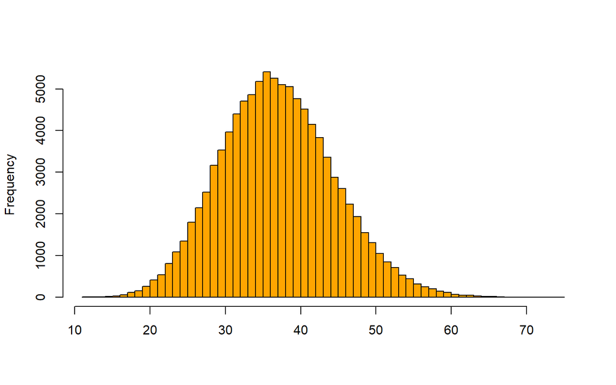

```r
rtheta = rbeta(100000, 50, 350)
y = vapply(rtheta, function(th) {
  rbinom(1, prob = th, size = 300)
}, numeric(1))
hist(y, breaks = 50, col = "orange", main = "", xlab = "")
```

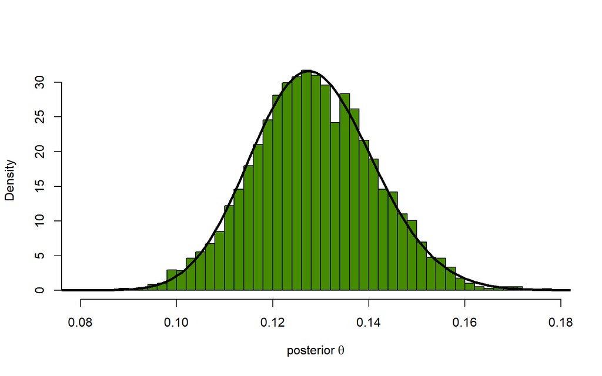

```r
thetaPostEmp = rtheta[ y == 40 ]
hist(thetaPostEmp, breaks = 40, col = "chartreuse4", main = "",
  probability = TRUE, xlab = expression("posterior"~theta))
densPostTheory  =  dbeta(thetas, 90, 610)
lines(thetas, densPostTheory, type="l", lwd = 3)
```

```r
mean(thetaPostEmp)
```

```
## [1] 0.1286695
```

```r
dtheta = thetas[2]-thetas[1]
sum(thetas * densPostTheory * dtheta)
```

```
## [1] 0.1285714
```

```r
thetaPostMC = rbeta(n = 1e6, 90, 610)
mean(thetaPostMC)
```

```
## [1] 0.1285617
```

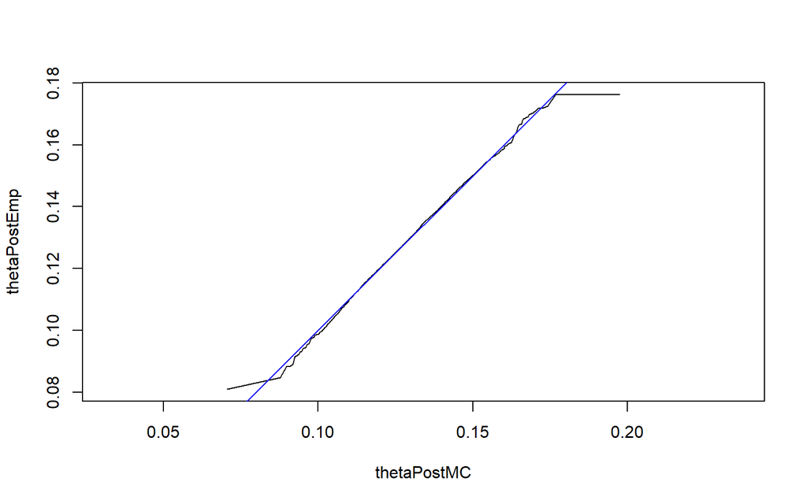

```r
qqplot(thetaPostMC, thetaPostEmp, type = "l", asp = 1)
abline(a = 0, b = 1, col = "blue")
```

### La distribución posterior también es una beta.

```r
densPost2 = dbeta(thetas, 115, 735)
mcPost2   = rbeta(1e6, 115, 735)

sum(thetas * densPost2 * dtheta)  # media por integración númerica
```

```
## [1] 0.1352941
```

```r
mean(mcPost2)
```

```
## [1] 0.1352791
```

```r
thetas[which.max(densPost2)]    # MAP estimate
```

```
## [1] 0.134
```

### Declaraciones de confianza para el parámetro de proporción

```r
quantile(mcPost2, c(0.025, 0.975))
```

```
##      2.5%     97.5%
## 0.1131352 0.1590637
```

## 2.10 Ejemplo: aparición de un patrón de nucleótidos en un genoma

```r
library("Biostrings")

library("BSgenome")
ag = available.genomes()
length(ag)
```

```
## [1] 107
```

```r
ag[1:2]
```

```
## [1] "BSgenome.Alyrata.JGI.v1"
## [2] "BSgenome.Amellifera.BeeBase.assembly4"
```

```r
# ocurrencia de la AGGAGGTmotivo
library("BSgenome.Ecoli.NCBI.20080805")
Ecoli
```

```
## E. coli genome:
## # organism: Escherichia coli (E. coli)
## # genome: 2008/08/05
## # provider: NCBI
## # release date: NA
## # 13 sequences:
## #   NC_008253 NC_008563 NC_010468 NC_004431 NC_009801 NC_009800 NC_002655
## #   NC_002695 NC_010498 NC_007946 NC_010473 NC_000913 AC_000091
## # (use 'seqnames()' to see all the sequence names, use the '$' or '[[' operator
## # to access a given sequence)
```

```r
shineDalgarno = "AGGAGGT"
ecoli = Ecoli$NC_010473
```

```r
#contar la ocurrencia del patrón en ventanas de ancho 50000

window = 50000
starts = seq(1, length(ecoli) - window, by = window)
ends   = starts + window - 1
numMatches = vapply(seq_along(starts), function(i) {
  countPattern(shineDalgarno, ecoli[starts[i]:ends[i]],
               max.mismatch = 0)
  }, numeric(1))
table(numMatches)
```

```
## numMatches
##  0  1  2  3  4
## 48 32  8  3  2
```

```r
sdMatches = matchPattern(shineDalgarno, ecoli, max.mismatch = 0)
```

Escribir sdMatchesen la línea de comando R para obtener un resumen de este objeto. Contiene las ubicaciones de las 65 coincidencias de patrones, representadas como un conjunto de las llamadas vistas de la secuencia original.

```r
betweenmotifs = gaps(sdMatches)
```

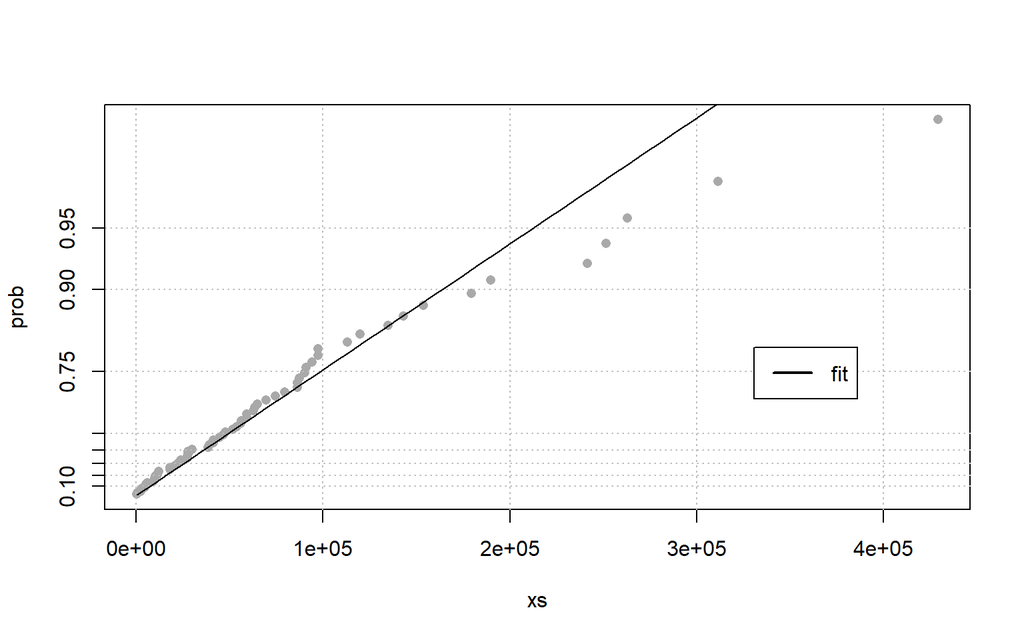

```r
library("Renext")
expplot(width(betweenmotifs), rate = 1/mean(width(betweenmotifs)),
        labels = "fit")
```

### 2.10.1 Modelado en el caso de dependencias

```r
library("BSgenome.Hsapiens.UCSC.hg19")

chr8  =  Hsapiens$chr8
CpGtab = read.table("https://raw.githubusercontent.com/unalmdei/GuiaBioinformatica/master/Datos/Cap2/model-based-cpg-islands-hg19.txt",
                    header = TRUE)
nrow(CpGtab)
```

```
## [1] 65699
```

```r
head(CpGtab)
```

```
##     chr  start    end length CpGcount GCcontent pctGC obsExp
## 1 chr10  93098  93818    721       32       403 0.559  0.572
## 2 chr10  94002  94165    164       12        97 0.591  0.841
## 3 chr10  94527  95302    776       65       538 0.693  0.702
## 4 chr10 119652 120193    542       53       369 0.681  0.866
## 5 chr10 122133 122621    489       51       339 0.693  0.880
## 6 chr10 180265 180720    456       32       256 0.561  0.893
```

```r
irCpG = with(dplyr::filter(CpGtab, chr == "chr8"),
         IRanges(start = start, end = end))
grCpG = GRanges(ranges = irCpG, seqnames = "chr8", strand = "+")
genome(grCpG) = "hg19"
```

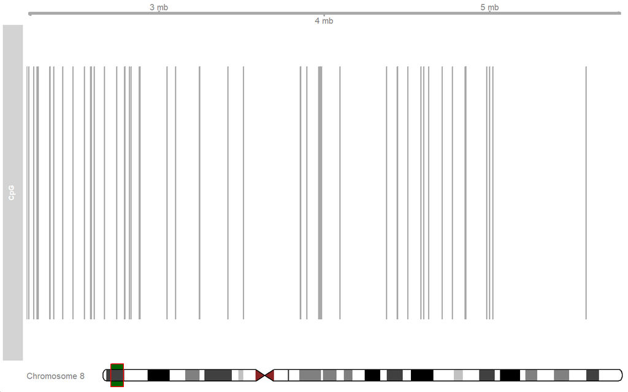

```r
library("Gviz")
ideo = IdeogramTrack(genome = "hg19", chromosome = "chr8")
plotTracks(
  list(GenomeAxisTrack(),
    AnnotationTrack(grCpG, name = "CpG"), ideo),
    from = 2200000, to = 5800000,
    shape = "box", fill = "#006400", stacking = "dense")
```

```r
CGIview    = Views(unmasked(Hsapiens$chr8), irCpG)
NonCGIview = Views(unmasked(Hsapiens$chr8), gaps(irCpG))
```

```r
seqCGI      = as(CGIview, "DNAStringSet")
seqNonCGI   = as(NonCGIview, "DNAStringSet")
dinucCpG    = sapply(seqCGI, dinucleotideFrequency)
dinucNonCpG = sapply(seqNonCGI, dinucleotideFrequency)
dinucNonCpG[, 1]
```

```
##  AA  AC  AG  AT  CA  CC  CG  CT  GA  GC  GG  GT  TA  TC  TG  TT
## 389 351 400 436 498 560 112 603 359 336 403 336 330 527 519 485
```

```r
NonICounts = rowSums(dinucNonCpG)
IslCounts  = rowSums(dinucCpG)
```

```r
#cadena de Markov de cuatro estados
TI  = matrix( IslCounts, ncol = 4, byrow = TRUE)
TnI = matrix(NonICounts, ncol = 4, byrow = TRUE)
dimnames(TI) = dimnames(TnI) =
  list(c("A", "C", "G", "T"), c("A", "C", "G", "T"))
```

```r
MI = TI /rowSums(TI)
MI
```

```
##            A         C         G         T
## A 0.20457773 0.2652333 0.3897678 0.1404212
## C 0.20128250 0.3442381 0.2371595 0.2173200
## G 0.18657245 0.3145299 0.3450223 0.1538754
## T 0.09802105 0.3352314 0.3598984 0.2068492
```

```r
MN = TnI / rowSums(TnI)
MN
```

```
##           A         C          G         T
## A 0.3351380 0.1680007 0.23080886 0.2660524
## C 0.3641054 0.2464366 0.04177094 0.3476871
## G 0.2976696 0.2029017 0.24655406 0.2528746
## T 0.2265813 0.1972407 0.24117528 0.3350027
```

```r
#relación logarítmica de verosimilitud
freqIsl = alphabetFrequency(seqCGI, baseOnly = TRUE,collapse = TRUE)[1:4]
freqIsl / sum(freqIsl)
```

```
##         A         C         G         T
## 0.1781693 0.3201109 0.3206298 0.1810901
```

```r
freqNon = alphabetFrequency(seqNonCGI, baseOnly = TRUE, collapse = TRUE)[1:4]
freqNon / sum(freqNon)
```

```
##         A         C         G         T
## 0.3008292 0.1993832 0.1993737 0.3004139
```

```r
alpha = log((freqIsl/sum(freqIsl)) / (freqNon/sum(freqNon)))
beta  = log(MI / MN)

x = "ACGTTATACTACG"
scorefun = function(x) {
  s = unlist(strsplit(x, ""))
  score = alpha[s[1]]
  if (length(s) >= 2)
    for (j in 2:length(s))
      score = score + beta[s[j-1], s[j]]
  score
}
scorefun(x)
```

```
##          A
## -0.2824623
```

```r
generateRandomScores = function(s, len = 100, B = 1000) {
  alphFreq = alphabetFrequency(s)
  isGoodSeq = rowSums(alphFreq[, 5:ncol(alphFreq)]) == 0
  s = s[isGoodSeq]
  slen = sapply(s, length)
  prob = pmax(slen - len, 0)
  prob = prob / sum(prob)
  idx  = sample(length(s), B, replace = TRUE, prob = prob)
  ssmp = s[idx]
  start = sapply(ssmp, function(x) sample(length(x) - len, 1))
  scores = sapply(seq_len(B), function(i)
    scorefun(as.character(ssmp[[i]][start[i]+(1:len)]))
  )
  scores / len
}
scoresCGI    = generateRandomScores(seqCGI)
scoresNonCGI = generateRandomScores(seqNonCGI)
```

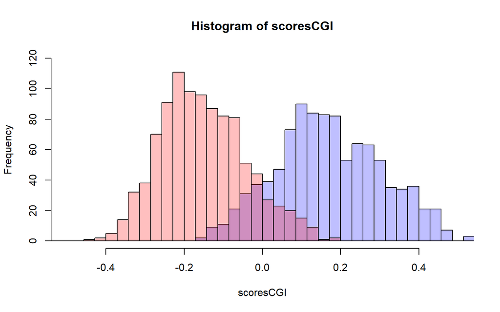

```r
br = seq(-0.6, 0.8, length.out = 50)
h1 = hist(scoresCGI,    breaks = br, plot = FALSE)
h2 = hist(scoresNonCGI, breaks = br, plot = FALSE)
plot(h1, col = rgb(0, 0, 1, 1/4), xlim = c(-0.5, 0.5), ylim=c(0,120))
plot(h2, col = rgb(1, 0, 0, 1/4), add = TRUE)
```

## 2.11 Resumen de este capítulo

En este capítulo experimentamos el yoga básico de la estadística: cómo volver de los datos a las posibles distribuciones generadoras y cómo estimar los parámetros que definen estas distribuciones. Modelos estadísticos Mostramos algunos modelos estadísticos específicos para experimentos con resultados categóricos (binomial y multinomial).

- **Bondad de ajuste:** Se uso diferentes visualizaciones y mostramos cómo ejecutar experimentos de simulación para probar si los datos podrían ajustarse a un modelo multinomial justo de cuatro cajas. Se encontró la estadística chi-cuadrado y vimos cómo comparar la simulación y la teoría usando un gráfico qq.
- **Estimación:** Se explicó los procedimientos de estimación de máxima verosimilitud y bayesianos. Estos enfoques se ilustraron con ejemplos relacionados con el descubrimiento de patrones de nucleótidos y estimaciones de haplotipos.
- **Distribuciones anteriores y posteriores:** Al evaluar datos de un tipo que se ha estudiado previamente, como los haplotipos, puede ser beneficioso calcular la distribución posterior de los datos. Esto permite incorporar la incertidumbre en la toma de decisiones, mediante un simple cálculo. La elección del anterior tiene poco efecto en el resultado siempre que haya suficientes datos.
- **Islas CpG y cadenas de Markov:** Se vio cómo las transiciones de la cadena de Markov pueden modelar las dependencias a lo largo de las secuencias de ADN. Esto se uso para generar puntajes basados en proporciones de probabilidad que nos permiten ver si las secuencias largas de ADN provienen de islas CpG o no. Cuando se hizó el histograma de puntajes, se vio una característica notable: parecía estar hecho de dos piezas.

### Pregunta N° 1

Una secuencia de tres nucleótidos (un codón ) tomada en una región codificante de un gen se puede transcribir en uno de los 20 aminoácidos posibles. Hay 4 3 = 64

posibles secuencias de codones, pero sólo 20 aminoácidos. Decimos que el código genético es redundante: hay varias formas de deletrear cada aminoácido.

La multiplicidad (el número de codones que codifican para el mismo aminoácido) varía de 2 a 6. Las diferentes grafías de codones de cada aminoácido no ocurren con las mismas probabilidades. Veamos los datos de la cepa de laboratorio estándar de tuberculosis (H37Rv):

```r
mtb = read.table("https://raw.githubusercontent.com/unalmdei/GuiaBioinformatica/master/Datos/Cap2/M_tuberculosis.txt", header = TRUE)
head(mtb, n = 4)
```

```
##   AmAcid Codon Number PerThous
## 1    Gly   GGG  25874    19.25
## 2    Gly   GGA  13306     9.90
## 3    Gly   GGT  25320    18.84
## 4    Gly   GGC  68310    50.82
```

```r
pro  =  mtb[ mtb$AmAcid == "Pro", "Number"]
pro/sum(pro)
```

```
## [1] 0.54302025 0.10532985 0.05859765 0.29305225
```

1. Explorar los datos mtbusando tablepara tabular las AmAcid y Codon .
2. ¿Cómo fue el PerThousvariable creada?
3. Escriba una función R que pueda aplicar a la tabla para encontrar cuál de los aminoácidos muestra el sesgo de codón , es decir, la desviación más fuerte de la distribución uniforme entre sus posibles grafías.

### pregunta N° 2

Muestre el contenido de GC en una ventana en ejecución a lo largo de la secuencia de Staphylococcus Aureus . Leer en una fasta de un archivo.

El conjunto de datos se encuentra disponible en [este link](https://github.com/unalmdei/GuiaBioinformatica/blob/master/Datos/Cap2/staphsequence.ffn.txt)

```r
staph = readDNAStringSet("https://raw.githubusercontent.com/unalmdei/GuiaBioinformatica/master/Datos/Cap2/staphsequence.ffn.txt", "fasta")
```

1. Mirar el completo staphobjeto y luego mostrar las primeras tres secuencias en el conjunto.

```r
staph[1:3, ]
```

```
## DNAStringSet object of length 3:
##     width seq                                               names
## [1]  1362 ATGTCGGAAAAAGAAATTTGGGA...AAAAAGAAATAAGAAATGTATAA lcl|NC_002952.2_c...
## [2]  1134 ATGATGGAATTCACTATTAAAAG...TTTTACCAATCAGAACTTACTAA lcl|NC_002952.2_c...
## [3]   246 GTGATTATTTTGGTTCAAGAAGT...TCATTCATCAAGGTGAACAATGA lcl|NC_002952.2_c...
```

```r
staph
```

```
## DNAStringSet object of length 2650:
##        width seq                                            names
##    [1]  1362 ATGTCGGAAAAAGAAATTTGGG...AAAGAAATAAGAAATGTATAA lcl|NC_002952.2_c...
##    [2]  1134 ATGATGGAATTCACTATTAAAA...TTACCAATCAGAACTTACTAA lcl|NC_002952.2_c...
##    [3]   246 GTGATTATTTTGGTTCAAGAAG...ATTCATCAAGGTGAACAATGA lcl|NC_002952.2_c...
##    [4]  1113 ATGAAGTTAAATACACTCCAAT...CAAGGTGAAATTATAAAGTAA lcl|NC_002952.2_c...
##    [5]  1932 GTGACTGCATTGTCAGATGTAA...TATGCAAACTTAGACTTCTAA lcl|NC_002952.2_c...
##    ...   ... ...
## [2646]   720 ATGACTGTAGAATGGTTAGCAG...ACTCCTTTACTTGAAAAATAA lcl|NC_002952.2_c...
## [2647]  1878 GTGGTTCAAGAATATGATGTAA...CTCCAAAGGGTGAGTGACTAA lcl|NC_002952.2_c...
## [2648]  1380 ATGGATTTAGATACAATTACGA...CAATTCTGCTTAGGTAAATAG lcl|NC_002952.2_c...
## [2649]   348 TTGGAAAAAGCTTACCGAATTA...TTTAATAAAAAGATTAAGTAA lcl|NC_002952.2_c...
## [2650]   138 ATGGTAAAACGTACTTATCAAC...CGTAAAGTTTTATCTGCATAA lcl|NC_002952.2_c...
```

2. Encuentre el contenido de GC en tsequence windows de ancho 100.

```r
letterFrequency(staph[[1]], letters = "ACGT", OR = 0)
```

```
##   A   C   G   T
## 522 219 229 392
```

```r
GCstaph = data.frame(
  ID = names(staph),
  GC = rowSums(alphabetFrequency(staph)[, 2:3] / width(staph)) * 100
)
```

3. Muestre el contenido de GC en una ventana deslizante como una fracción.

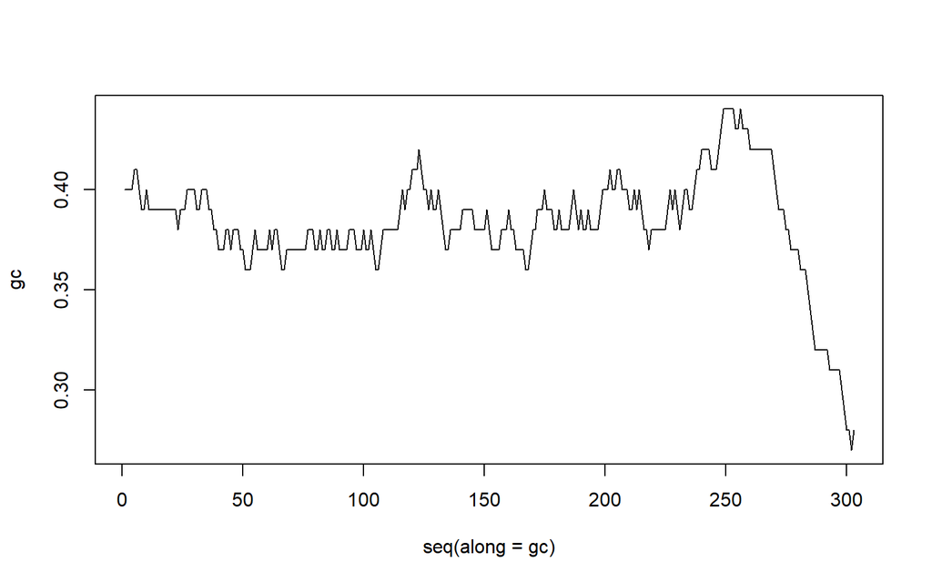

```r
window = 100
gc = rowSums( letterFrequencyInSlidingView(staph[[364]], window,
      c("G","C")))/window
plot(x = seq(along = gc), y = gc, type = "l")
```

4. ¿Cómo podríamos visualizar las tendencias generales de estas proporciones a lo largo de la secuencia?

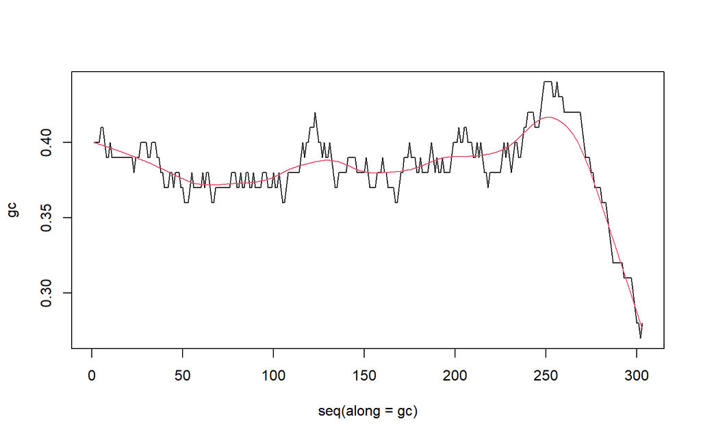

```r
plot(x = seq(along = gc), y = gc, type = "l")
lines(lowess(x = seq(along = gc), y = gc, f = 0.2), col = 2)
```